# CustomerLens-Analytics

La Estrategia Multicanal: ¿Suma o Sinergia?

Pablo Oliva Muñoz

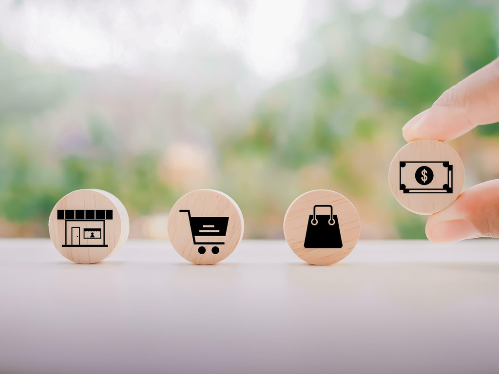

## 1 Introducción

La adopción de estrategias omnicanal es uno de los mayores vectores de inversión en el retail moderno. Analíticamente es sencillo observar que un cliente que usa múltiples canales (Web, Tienda, Catálogo) gasta más que uno monocanal. Sin embargo, para justificar contablemente la inversión en integrar estos canales, debemos responder a una pregunta financiera y analítica más profunda:

> **¿Ese aumento de gasto es una simple suma de ventas independientes, o existe un efecto multiplicador (sinergias) al combinar canales?**

La diferencia entre ambas hipótesis tiene implicaciones de negocio completamente distintas:

- Si los canales son **independientes y aditivos**, cada uno aporta su contribución propia al gasto total y la empresa debería optimizar cada canal por separado según su ROI individual.
- Si existen **sinergias** (efecto multiplicador), la combinación de canales genera un gasto extra que va más allá de la suma de sus partes. En ese caso, la empresa debería priorizar estrategias que incentiven el uso simultáneo de múltiples canales.

Para responder necesitamos ir más allá de la exploración visual: aplicaremos el **análisis de la varianza (ANOVA)** para confirmar que las diferencias son reales, y modelos de **regresión con términos de interacción** para detectar si esas sinergias existen matemáticamente.

### Objetivos

1. Confirmar estadísticamente que el gasto difiere según el número de canales activos (ANOVA).
2. Modelizar el gasto total como una **suma aditiva** de los distintos canales, bajo la hipótesis de ausencia de sinergia.
3. Extender el modelo incluyendo **interacciones** entre canales para evaluar la presencia de un efecto multiplicador en el gasto.
4. Comparar el gasto predicho en todas las combinaciones posibles de canales.

## 2 Preparación del Entorno y los Datos

```r
library(dplyr)
library(readr)
library(ggplot2)
library(tidyr)
library(scales)
library(ggpubr)
library(broom)
library(car)
```

```r
data <- read_csv("./data/marketing_campaign_processed.csv", show_col_types = FALSE)

data$Education      <- factor(data$Education,
                              levels = c("Basic","2n Cycle","Graduation","Master","PhD"),
                              ordered = TRUE)
data$Marital_Status <- factor(data$Marital_Status,
                              levels = c("Single","Together","Married","Divorced","Widow"))

# Reconstruimos Num_Channels
data <- data %>%
  mutate(
    Canal_Web     = as.integer(NumWebPurchases     > 0),
    Canal_Catalog = as.integer(NumCatalogPurchases > 0),
    Canal_Store   = as.integer(NumStorePurchases   > 0),
    Num_Channels  = Canal_Web + Canal_Catalog + Canal_Store
  ) %>%
  filter(Num_Channels >= 1)

data$Num_Channels_f <- factor(data$Num_Channels, levels = 1:3,
                               labels = c("1 canal", "2 canales", "3 canales"))

cat("Observaciones disponibles:", nrow(data), "\n")
```

```
## Observaciones disponibles: 2202
```

```r
table(data$Num_Channels_f)
```

```
##
##   1 canal 2 canales 3 canales
##        37       543      1622
```

```r
# Aseguramos que Income no tenga NAs
data <- data %>% filter(!is.na(Income))
cat("Observaciones tras eliminar Income NA:", nrow(data), "\n")
```

```
## Observaciones tras eliminar Income NA: 2202
```

## 3 ANOVA: ¿Es Real la Diferencia entre Grupos?

**Objetivo 1:** Confirmar estadísticamente que el gasto difiere según el número de canales activos.

Antes de rastrear sinergias, necesitamos descartar que las diferencias de gasto observadas entre perfiles sean fruto del azar. Si la varianza interna de los grupos es mayor que la diferencia media entre ellos, el modelo multiplicador carece de base estadística.

### Verificación de homocedasticidad — Test de Levene

El ANOVA clásico asume que la varianza del gasto es igual en los tres grupos (monocanal, bicanal, tricanal). Verificamos esta premisa con el **Test de Levene** antes de elegir la variante de ANOVA más adecuada.

```r
# Test de Levene: H0 = varianzas iguales entre grupos
levene_result <- leveneTest(Total_Spending ~ Num_Channels_f, data = data)
print(levene_result)
```

```
## Levene's Test for Homogeneity of Variance (center = median)
##         Df F value    Pr(>F)
## group    2  561.95 < 2.2e-16 ***
##       2199
## ---
## Signif. codes:  0 '***' 0.001 '**' 0.01 '*' 0.05 '.' 0.1 ' ' 1
```

```r
if (levene_result$`Pr(>F)`[1] < 0.05) {
  cat("\nConclusión: varianzas DESIGUALES entre grupos (p < 0.05).\n")
  cat("-> Se usará el ANOVA de Welch, robusto ante heterocedasticidad.\n")
} else {
  cat("\nConclusión: varianzas homogéneas (p >= 0.05). ANOVA clásico sería válido.\n")
}
```

```
##
## Conclusión: varianzas DESIGUALES entre grupos (p < 0.05).
## -> Se usará el ANOVA de Welch, robusto ante heterocedasticidad.
```

Esto indica que las varianzas entre grupos son desiguales. Esto es consistente con lo esperado en variables de gasto económico, que suelen mostrar distribuciones asimétricas y varianzas crecientes a medida que aumenta la media, como ocurre en datos multicanal donde los consumidores tricanal presentan un rango de gasto mucho mayor. En este contexto, el ANOVA de Welch (var.equal = FALSE) constituye la opción estadísticamente adecuada.

### ANOVA de Welch

```r
# ANOVA de Welch: robusto ante varianzas desiguales entre grupos
anova_welch <- oneway.test(Total_Spending ~ Num_Channels_f, data = data, var.equal = FALSE)
anova_welch
```

```
##
##  One-way analysis of means (not assuming equal variances)
##
## data:  Total_Spending and Num_Channels_f
## F = 1236.7, num df = 2.00, denom df = 94.48, p-value < 2.2e-16
```

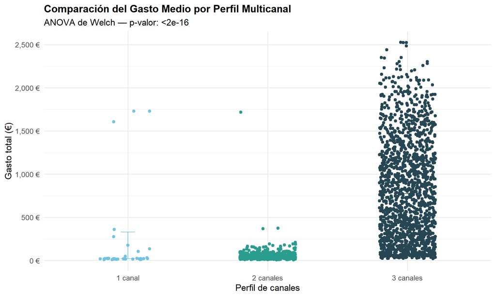

```r
# Gráfico de medias con intervalos de confianza y puntos individuales
ggline(data, x = "Num_Channels_f", y = "Total_Spending",
       add        = c("mean_ci", "jitter"),
       color      = "Num_Channels_f",
       palette    = c("#74C2E1", "#2A9D8F", "#264653"),
       point.size = 0.5,
       alpha      = 0.3,
       title      = "Comparación del Gasto Medio por Perfil Multicanal",
       subtitle   = paste("ANOVA de Welch — p-valor:", format.pval(anova_welch$p.value, digits = 3)),
       xlab       = "Perfil de canales",
       ylab       = "Gasto total (€)") +
  scale_y_continuous(labels = dollar_format(prefix = "", suffix = " €")) +
  theme_minimal(base_size = 13) +
  theme(plot.title = element_text(face = "bold", size = 15),
        legend.position = "none")
```

```r
post_hoc <- pairwise.t.test(data$Total_Spending, data$Num_Channels_f,
                            p.adjust.method = "bonferroni",
                            pool.sd = FALSE)

print("p-valores ajustados por Bonferroni (Varianzas desiguales):")
```

```
## [1] "p-valores ajustados por Bonferroni (Varianzas desiguales):"
```

```r
print(post_hoc$p.value)
```

```
##                1 canal 2 canales
## 2 canales 3.696874e-01        NA
## 3 canales 2.178701e-09         0
```

**Hallazgo — Objetivo 1 resuelto:** El p-valor del ANOVA de Welch es prácticamente cero (2.2e-16), lo que descarta que las diferencias de gasto sean casuales.

Los clientes que usan los 3 canales gastan muchísimo más que el resto. Sin embargo, los datos no muestran una diferencia real de gasto entre usar 1 o 2 canales (probablemente porque tenemos muy pocos clientes monocanal para comparar bien). Pero lo que realmente importa para el negocio es que **el gran salto de dinero ocurre al pasar de 2 a 3 canales**.

Sabiendo que usar los tres canales dispara el gasto, la gran pregunta que nos queda es: ¿ese subidón es solo la suma normal de lo que gastarían en cada sitio por separado, o existe un efecto multiplicador al combinarlos?

## 4 Modelización: Buscando el “Efecto Sinergia”

**Objetivos 2-3:** Comparar modelos de gasto para identificar posibles efectos multiplicadores entre canales.

Construimos tres modelos de forma progresiva, cada uno respondiendo a una pregunta diferente:

| Modelo | Pregunta que responde | Formulación R |
| --- | --- | --- |
| **Modelo 1 — Suma** | ¿Cada canal contribuye de forma independiente? | `~Web + Catálogo + Tienda` |
| **Modelo 2 — Sinergia** | ¿Los canales se potencian entre sí? | `~(Web + Catálogo + Tienda)^3` |
| **Modelo 3 — Controlado** | ¿La sinergia persiste al aislar el efecto de los ingresos? | `~(Web + Catálogo + Tienda)^3 + Income` |

El tercer modelo introduce `Income` como variable de control. Una hipótesis de negocio habitual es que los clientes tricanales simplemente tienen ingresos más altos. Para descartar que la sinergia detectada sea simplemente un reflejo de mayor capacidad adquisitiva, controlamos por ingresos y comprobamos si el efecto se mantiene.

### Paso 1: ¿Los canales son independientes?

```r
# Modelo 1: Efectos aditivos — H0: los canales son independientes
mod_suma <- lm(
  Total_Spending ~ NumWebPurchases + NumCatalogPurchases + NumStorePurchases,
  data = data
)

# Modelo 2: Interacciones ^3 — incluye pares Y el trío Web×Catálogo×Tienda
mod_sinergia <- lm(
  Total_Spending ~ (NumWebPurchases + NumCatalogPurchases + NumStorePurchases)^3,
  data = data
)

# Modelo 3: Igual que Modelo 2 pero controlando por ingresos del cliente
mod_controlado <- lm(
  Total_Spending ~ (NumWebPurchases + NumCatalogPurchases + NumStorePurchases)^3 + Income,
  data = data
)

# --- ¿Añadir interacciones mejora el modelo? (Paso 1 vs Paso 2) ---
r2_suma      <- round(summary(mod_suma)$adj.r.squared * 100, 2)
r2_sinergia  <- round(summary(mod_sinergia)$adj.r.squared * 100, 2)
r2_control   <- round(summary(mod_controlado)$adj.r.squared * 100, 2)

cat("=== Comparacion de R2 ajustados ===\n")
```

```
## === Comparacion de R2 ajustados ===
```

```r
cat("Modelo 1 — Suma       :", r2_suma, "%\n")
```

```
## Modelo 1 — Suma       : 72.6 %
```

```r
cat("Modelo 2 — Sinergia   :", r2_sinergia, "%\n")
```

```
## Modelo 2 — Sinergia   : 74.17 %
```

```r
cat("Modelo 3 — Controlado :", r2_control, "%\n\n")
```

```
## Modelo 3 — Controlado : 76.16 %
```

```r
# F-test: Modelo 1 vs Modelo 2 (¿aportan algo las interacciones?)
ftest12 <- anova(mod_suma, mod_sinergia)
cat("=== F-test Modelo 1 vs Modelo 2 ===\n")
```

```
## === F-test Modelo 1 vs Modelo 2 ===
```

```r
cat("F =", round(ftest12$F[2], 3), "| p-valor =",
    format.pval(ftest12$`Pr(>F)`[2], digits = 4, eps = 1e-16), "\n")
```

```
## F = 34.374 | p-valor = < 1e-16
```

```r
if (ftest12$`Pr(>F)`[2] < 0.05) {
  cat("-> SI: las interacciones entre canales mejoran significativamente el modelo\n")
} else {
  cat("-> NO: los canales actuan de forma independiente\n")
}
```

```
## -> SI: las interacciones entre canales mejoran significativamente el modelo
```

```r
# F-test: Modelo 2 vs Modelo 3 (¿Income explica algo adicional?)
ftest23 <- anova(mod_sinergia, mod_controlado)
cat("\n=== F-test Modelo 2 vs Modelo 3 ===\n")
```

```
##
## === F-test Modelo 2 vs Modelo 3 ===
```

```r
cat("F =", round(ftest23$F[2], 3), "| p-valor =",
    format.pval(ftest23$`Pr(>F)`[2], digits = 4, eps = 1e-16), "\n")
```

```
## F = 184.138 | p-valor = < 1e-16
```

```r
if (ftest23$`Pr(>F)`[2] < 0.05) {
  cat("-> Income aporta poder explicativo adicional al modelo\n")
  cat("-> Si las interacciones siguen siendo significativas en Modelo 3,\n")
  cat("   la sinergia es REAL e independiente del nivel de ingresos\n")
} else {
  cat("-> Income NO aporta poder explicativo adicional (p >= 0.05)\n")
  cat("-> El Modelo 2 ya captura toda la variacion relevante\n")
}
```

```
## -> Income aporta poder explicativo adicional al modelo
## -> Si las interacciones siguen siendo significativas en Modelo 3,
##    la sinergia es REAL e independiente del nivel de ingresos
```

### Paso 2: ¿La sinergia es real o la explican los ingresos?

```r
tidy(mod_sinergia) %>%
  filter(p.value < 0.05) %>%
  arrange(p.value) %>%
  mutate(
    Significativo = case_when(p.value < 0.001 ~ "***", p.value < 0.01 ~ "**",
                              p.value < 0.05  ~ "*",  TRUE ~ ""),
    across(c(estimate, std.error, statistic), ~ round(., 3))
  ) %>%
  rename(Término = term, `Efecto (€)` = estimate,
         `Error Std.` = std.error, `t-valor` = statistic, `p-valor` = p.value)
```

```
## # A tibble: 7 × 6
##   Término            `Efecto (€)` `Error Std.` `t-valor` `p-valor` Significativo
##   <chr>                     <dbl>        <dbl>     <dbl>     <dbl> <chr>
## 1 NumCatalogPurchas…        84.3          5.68     14.8   1.59e-47 ***
## 2 NumWebPurchases:N…        16.1          1.52     10.6   1.86e-25 ***
## 3 NumWebPurchases:N…        -2.11         0.24     -8.79  2.90e-18 ***
## 4 NumStorePurchases         64.2          7.70      8.35  1.22e-16 ***
## 5 (Intercept)             -188.          27.0      -6.95  4.84e-12 ***
## 6 NumCatalogPurchas…         4.29         1.29      3.33  8.85e- 4 ***
## 7 NumWebPurchases:N…         2.48         1.24      1.99  4.64e- 2 *
```

```r
tidy(mod_controlado) %>%
  filter(p.value < 0.05) %>%
  arrange(p.value) %>%
  mutate(
    Significativo = case_when(p.value < 0.001 ~ "***", p.value < 0.01 ~ "**",
                              p.value < 0.05  ~ "*",  TRUE ~ ""),
    across(c(estimate, std.error, statistic), ~ round(., 3))
  ) %>%
  rename(Término = term, `Efecto (€)` = estimate,
         `Error Std.` = std.error, `t-valor` = statistic, `p-valor` = p.value)
```

```
## # A tibble: 8 × 6
##   Término            `Efecto (€)` `Error Std.` `t-valor` `p-valor` Significativo
##   <chr>                     <dbl>        <dbl>     <dbl>     <dbl> <chr>
## 1 Income                    0.005        0         13.6   2.45e-40 ***
## 2 NumCatalogPurchas…       65.8          5.62      11.7   1.08e-30 ***
## 3 (Intercept)            -284.          26.9      -10.5   2.06e-25 ***
## 4 NumWebPurchases:N…       15.0          1.46      10.2   5.21e-24 ***
## 5 NumWebPurchases:N…       -1.92         0.231     -8.33  1.37e-16 ***
## 6 NumStorePurchases        47.6          7.49       6.36  2.50e-10 ***
## 7 NumCatalogPurchas…        4.66         1.24       3.77  1.70e- 4 ***
## 8 NumWebPurchases:N…        2.93         1.20       2.45  1.44e- 2 *
```

**Hallazgo — Objetivos 2, 3 resueltos:** Los tres modelos mejoran progresivamente el ajuste: R² ajustado del 72,6 % (Modelo 1), al 74,17 % (Modelo 2) al **76,15 % (Modelo 3)**

Las interacciones entre pares de canales son positivas y significativas — **Web × Catálogo (+15–16 €)**, Catálogo × Tienda (+4–5 €), Web × Tienda (+2–3 €) — lo que confirma la existencia de efectos multiplicadores. La interacción triple presenta una saturación leve (–2 €): el valor incremental de combinar los tres canales viene principalmente de los pares, aunque el cliente tricanal sigue acumulando todas las sinergias simultáneamente, lo que lo convierte en el **perfil de mayor gasto predicho.**

Controlando por ingresos (Modelo 3), las interacciones siguen siendo significativas: la sinergia es un comportamiento real de los clientes, no solo un efecto del nivel de renta. El Modelo 3 es la referencia analítica del resto del notebook. **En otras palabras, el ingreso marca el gasto base de cada cliente, y la combinación de canales añade valor extra por encima de ese nivel.**

## 5 Visualización de la Sinergia: El Gráfico Clave

**Objetivo 4**: Comparar el gasto predicho en todas las combinaciones posibles de canales.

El gráfico que responde directamente la pregunta de investigación: usando el **Modelo 3 — Controlado** (el mejor), calculamos el gasto predicho para cada **perfil de canal posible**.

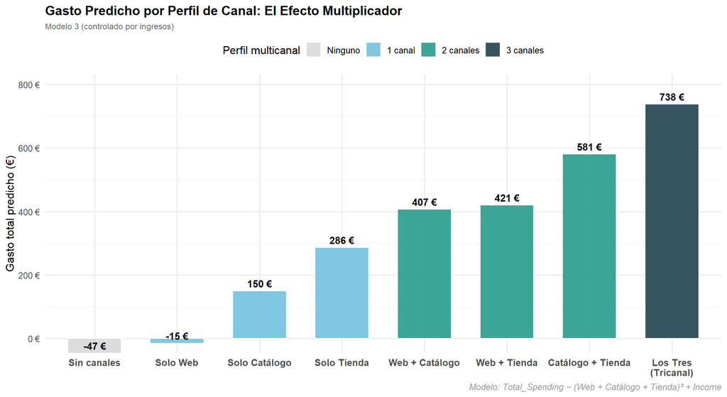

```r
WEB_TIPICO     <- 5   # compras web activas
CAT_TIPICO     <- 3   # compras catálogo activas
TIENDA_TIPICA  <- 7   # compras tienda activas
INCOME_MED     <- median(data$Income, na.rm = TRUE)

# 8 perfiles: todas las combinaciones posibles de activar/desactivar cada canal
perfiles <- data.frame(
  NumWebPurchases     = c(0, WEB_TIPICO, 0,         0,            WEB_TIPICO, WEB_TIPICO, 0,           WEB_TIPICO),
  NumCatalogPurchases = c(0, 0,          CAT_TIPICO, 0,            CAT_TIPICO, 0,          CAT_TIPICO,  CAT_TIPICO),
  NumStorePurchases   = c(0, 0,          0,          TIENDA_TIPICA, 0,          TIENDA_TIPICA, TIENDA_TIPICA, TIENDA_TIPICA),
  Income              = INCOME_MED
)
perfiles$Pred <- predict(mod_controlado, newdata = perfiles)

perfiles <- perfiles %>%
  mutate(
    Perfil = c("Sin canales",
               "Solo Web", "Solo Catálogo", "Solo Tienda",
               "Web + Catálogo", "Web + Tienda", "Catálogo + Tienda",
               "Los Tres\n(Tricanal)"),
    N_canales = c(0, 1, 1, 1, 2, 2, 2, 3),
    Color_group = factor(N_canales,
                         labels = c("Ninguno", "1 canal", "2 canales", "3 canales"))
  ) %>%
  # Ordenar por número de canales para que quede narrativo
  mutate(Perfil = factor(Perfil, levels = Perfil))

ggplot(perfiles, aes(x = Perfil, y = Pred, fill = Color_group)) +
  geom_col(width = 0.65, color = "white", linewidth = 0.5, alpha = 0.92) +
  geom_text(aes(label = paste0(round(Pred, 0), " €")),
            vjust = -0.5, fontface = "bold", size = 3.8) +
  scale_fill_manual(
    values = c("Ninguno"   = "#D9D9D9",
               "1 canal"   = "#74C2E1",
               "2 canales" = "#2A9D8F",
               "3 canales" = "#264653"),
    name = "Perfil multicanal"
  ) +
  scale_y_continuous(labels = dollar_format(prefix = "", suffix = " €"),
                     expand = expansion(mult = c(0, 0.12))) +
  labs(
    title    = "Gasto Predicho por Perfil de Canal: El Efecto Multiplicador",
    subtitle = paste0("Modelo 3 (controlado por ingresos)"),
    x        = NULL,
    y        = "Gasto total predicho (€)",
    caption  = "Modelo: Total_Spending ~ (Web + Catálogo + Tienda)³ + Income"
  ) +
  theme_minimal(base_size = 12) +
  theme(
    plot.title    = element_text(face = "bold", size = 14),
    plot.subtitle = element_text(color = "gray40", size = 9),
    plot.caption  = element_text(color = "gray60", face = "italic"),
    axis.text.x   = element_text(face = "bold", size = 10),
    legend.position = "top"
  )
```

**Hallazgo — Objetivo 4 resuelto:** El gráfico responde de forma directa: el perfil **“Los Tres (Tricanal)”** genera un gasto predicho notablemente superior no solo a cualquier perfil monocanal, sino también a cualquier perfil bicanal. Si los canales fuesen puramente aditivos, “Los Tres” debería valer exactamente la suma de “Solo Web” + “Solo Catálogo” + “Solo Tienda”. Que supere esa suma es la definición exacta de **sinergia**: el valor de la combinación excede la suma de las partes.

## 6 Comparativa Final de Modelos

```r
data.frame(
  Modelo        = c("Modelo 1 — Suma (aditivo)",
                    "Modelo 2 — Sinergia (interacciones)",
                    "Modelo 3 — Controlado (sinergia + Income)"),
  `R²`          = c(round(summary(mod_suma)$r.squared, 4),
                     round(summary(mod_sinergia)$r.squared, 4),
                     round(summary(mod_controlado)$r.squared, 4)),
  `R² ajustado` = c(round(summary(mod_suma)$adj.r.squared, 4),
                     round(summary(mod_sinergia)$adj.r.squared, 4),
                     round(summary(mod_controlado)$adj.r.squared, 4)),
  AIC           = c(round(AIC(mod_suma), 0),
                    round(AIC(mod_sinergia), 0),
                    round(AIC(mod_controlado), 0)),
  RMSE          = c(round(sqrt(mean(resid(mod_suma)^2)), 1),
                    round(sqrt(mean(resid(mod_sinergia)^2)), 1),
                    round(sqrt(mean(resid(mod_controlado)^2)), 1)),
  check.names   = FALSE
)
```

```
##                                      Modelo     R² R² ajustado   AIC  RMSE
## 1                 Modelo 1 — Suma (aditivo) 0.7264      0.7260 31597 315.2
## 2       Modelo 2 — Sinergia (interacciones) 0.7425      0.7417 31471 305.8
## 3 Modelo 3 — Controlado (sinergia + Income) 0.7625      0.7616 31295 293.7
```

**Interpretación:** La progresión de los tres modelos es la conclusión cuantitativa del análisis. Cada fila de la tabla debe leerse como una respuesta a una pregunta: el **Modelo 1** establece cuánto explican los canales por separado; el **Modelo 2** añade cómo interaccionan entre sí — si su AIC baja y su R² ajustado sube respecto al Modelo 1, existe sinergia real; el **Modelo 3** demuestra si esa sinergia sobrevive al quitar el posible efecto confusor de los ingresos. RMSE más bajo significa mejor predicción del gasto real en euros.

## 7 Conclusiones

### Respuesta a la pregunta de investigación

> **¿Ese aumento de gasto es una simple suma de ventas independientes, o existe un efecto multiplicador (sinergias) al combinar canales?**

**Respuesta:** La respuesta es clara: **existe un efecto multiplicador real.** El aumento de gasto al combinar canales no se explica como una suma de contribuciones independientes. Las combinaciones generan gasto extra por encima de lo que cada canal aportaría por separado, y ese efecto persiste incluso entre clientes del mismo nivel de ingresos.

### Síntesis por objetivos

[output not shown]

### Implicaciones para el negocio

**1. La multicanalidad no es redistribución de ventas, es creación de valor nuevo**

Cada canal adicional no solo aporta sus propias ventas, potencia las de los canales que el cliente ya utilizaba. La empresa está ante un mecanismo de creación de valor, no de redistribución.

**3. El perfil de máximo valor: tricanal con renta alta**

De los 1.622 tricanales, los de renta alta son el subgrupo de mayor valor absoluto: no solo gastan más por su capacidad adquisitiva, sino que al utilizar los tres canales simultáneamente acumulan todas las sinergias de pares detectadas por el Modelo 3. La captación y fidelización de este perfil debería ser la prioridad estratégica de cualquier campaña orientada a maximizar el valor de vida del cliente.

## 8 Referencias

- Cyberclick. “Las 4 P del marketing: qué son y ejemplos”. Recuperado de: https://www.cyberclick.es/numerical-blog/las-4-p-del-marketing-que-debes-aprender
- MDirector. “Cómo diseñar una estrategia omnicanal ganadora”. Recuperado de: https://www.mdirector.com/blog/estrategia-omnicanal/
- Salesforce. “Omnichannel Strategy Benefits”. Recuperado de: https://www.salesforce.com/eu/blog/omnichannel-strategy-benefits/